# DADA2: Run 1

Eva Kim

10/23/2024

# 1 General Information

### 1.0.1 Info for data analysis

For the lung tissue samples, primer sequences have been removed. However, for fecal samples, they will have to be removed.

### 1.0.3 Codes

Please note that many of the coding lines below are from Dr. Callahan’s [DADA2 tutorial](https://benjjneb.github.io/dada2/tutorial.html).

### 1.0.4 Data availability

For reproducibility, this file assumes that you have download the files from BioProject PRJNA1111477 of NCBI SRA database in `.fastq` format. There should be 293 SRR files under that BioProject. For convenience, I have also downloaded the metadata to convert SRR names to sample names.

# 2 Load libraries

```r
library(dada2)
library(readr)
library(stringr)
library(dplyr)
library(tibble)
library(magrittr)
library(phyloseq)
library(ggplot2)
library(fs)
library(tidyr)
library(ShortRead)
library(Biostrings)
library(tidyverse)
library(vegan)
library(decontam)
library(pals)
library(tools)
library(seqTools)
library(DT)
```

# 3 Directories

```r
rm(list=ls()) # clear environment

# Project-related directories: change as needed!
dmc.dir = file.path("/hpc/group/dmc/Eva") # CHANGE ME to parent directory
git.dir = file.path(dmc.dir, "GLP_KO_Microbiome_Study") # CHANGE ME to Git Directory
data.dir = path.expand(file.path(dmc.dir, paste0("tmp_GLPKO_data"))) # CHANGE ME to where sequencing files are stored (.fastq.gz)

scratch.dir = file.path("/work/yk132/GLP_KO_Microbiome_Study") # CHANGE ME to project work directory
output.dir = path.expand(file.path(scratch.dir, paste0("output")))

map.file = file.path(git.dir, "Metadata_GLP1.csv")
meta.df = read_csv(map.file, show_col_types = FALSE)

sra.file = file.path(git.dir, "GLP1_study_SraRunTable.txt")
sra.df = read_csv(sra.file, show_col_types = FALSE)

if (dir_exists(scratch.dir)) {
  dir_delete(scratch.dir)
}
dir_create(scratch.dir)

filt.dir = path.expand(file.path(scratch.dir,paste0("filt")))
dir_create(filt.dir)

Sys.setenv(OUT_DIR = output.dir)
Sys.setenv(SCRATCH_DIR = scratch.dir)
Sys.setenv(DATA_DIR = data.dir)
Sys.setenv(FILT_DIR = filt.dir)

# Ref database
### Silva v138.1 database formatted for DADA2 is available for download: https://zenodo.org/records/4587955
database.dir = file.path("/hpc/group/dmc/Eva/databases/silva_v138.1") # CHANGE ME to database folder
silva_v138.ref = path.expand(file.path(database.dir, paste0("silva_nr99_v138.1_train_set.fa.gz")))
silva_v138.species.ref =  path.expand(file.path(database.dir, paste0("silva_species_assignment_v138.1.fa.gz")))
```

```r
scratch.dir
```

```
## [1] "/work/yk132/GLP_KO_Microbiome_Study"
```

# 4 Check Metadata and files

After files have been downloaded, there should be:

```r
293*2
```

```
## [1] 586
```

586 files.

```r
sra.df %>% select(`Library Name`, Run) %>%
  dplyr::rename(Label = `Library Name`) %>%
  left_join(meta.df, by = "Label") -> meta.run

meta.run
```

| Label | Run | Concentration-(ng/uL) | Sample_type | Type | Sequencing_Run | Mouse | Cage-Mouse | Genotype | Sex | Diet | Intranasal_Treatment | Surgery | Intranasal_Dose | Cohort | Cage | Week | Lung_index | Kit | DNA_ng_ul_raw | Sample_Label | Cage_Notation | Feces_weight | Orig_label | Notes | Glucose_tolerance_wk0_0m | Glucose_tolerance_wk0_10m | Glucose_tolerance_wk0_30m | Glucose_tolerance_wk0_90m | Weight_g_wk0 | … |
| --- | --- | --- | --- | --- | --- | --- | --- | --- | --- | --- | --- | --- | --- | --- | --- | --- | --- | --- | --- | --- | --- | --- | --- | --- | --- | --- | --- | --- | --- | --- |
| 227 | SRR29054901 | NA | Fecal | True Sample | 2 | JI-727 | 1489566-4 | WT | Female | Normal_Chow | HDM | None | 50ug/40ul | 2 | 1489566 | 10 | NA | PS_2 | 97.00 | NA | 566-4 | 33.5 | 566-4 Fecal wk 10 | NA | 212 | 418 | 311 | 162 | 17.43 | … |
| 226 | SRR29054902 | NA | Fecal | True Sample | 2 | JI-742 | 1489601-3 | WT | Male | Normal_Chow | HDM | None | 50ug/40ul | 2 | 1489601 | 10 | NA | PS_2 | 42.90 | NA | 601-3 | 23.0 | 601-3 Fecal wk 10 | NA | 175 | 342 | 317 | 166 | 22.59 | … |
| 225 | SRR29054903 | NA | Fecal | True Sample | 2 | JI-743 | 1489601-4 | WT | Male | Normal_Chow | PBS | None | 40ul | 2 | 1489601 | 10 | NA | PS_2 | 18.20 | NA | 601-4 | 22.0 | 601-4 Fecal wk 10 | NA | 168 | 391 | 317 | 170 | 23.06 | … |
| 224 | SRR29054904 | NA | Fecal | True Sample | 2 | JI-761 | 1489602-2 | WT | Female | High_Fat_Diet | PBS | None | 40ul | 2 | 1489602 | 10 | NA | PS_2 | 51.00 | NA | 602-2 | 36.5 | 602-2 Fecal wk 10 | NA | 166 | 291 | 234 | 141 | 19.71 | … |
| 223 | SRR29054905 | NA | Fecal | True Sample | 2 | JI-741 | 1489601-2 | WT | Male | Normal_Chow | HDM | None | 50ug/40ul | 2 | 1489601 | 10 | NA | PS_2 | 161.00 | NA | 601-2 | 83.0 | 601-2 Fecal wk 10 | NA | 171 | 354 | 259 | 136 | 22.62 | … |
| 222 | SRR29054906 | NA | Fecal | True Sample | 2 | JI-726 | 1489566-3 | WT | Female | Normal_Chow | PBS | None | 40ul | 2 | 1489566 | 13 | NA | PS_2 | 78.40 | NA | JI-726 | 54.0 | JI-726 Fecal wk 13 | NA | 194 | 395 | 325 | 172 | 19.54 | … |
| 221 | SRR29054907 | NA | Fecal | True Sample | 2 | JI-761 | 1489602-2 | WT | Female | High_Fat_Diet | PBS | None | 40ul | 2 | 1489602 | 0 | NA | PS_2 | 40.90 | NA | 602-2 | 25.5 | 602-2 Fecal wk 0 | NA | 166 | 291 | 234 | 141 | 19.71 | … |
| 220 | SRR29054908 | NA | Fecal | Neg Control | 2 | Blank_2 | NA | NA | NA | NA | NA | NA | NA | NA | NA | NA | NA | PS_2 | 0.01 | Kit_blank_6 | NA | NA | Kit_blank_6 | NA | NA | NA | NA | NA | NA | … |
| 219 | SRR29054909 | NA | Fecal | True Sample | 2 | JI-759 | 1522806/1489569-2 | WT | Female | High_Fat_Diet | PBS | Sham | 40ul | 2 | 1522806 | 10 | NA | PS_2 | 87.90 | NA | 569-2 | 60.0 | 569-2 Fecal wk 10 | NA | 170 | 291 | 198 | 152 | 20.60 | … |
| 218 | SRR29054910 | NA | Fecal | True Sample | 2 | JI-761 | 1489602-2 | WT | Female | High_Fat_Diet | PBS | None | 40ul | 2 | 1489602 | 13 | NA | PS_2 | 17.80 | NA | JI-761 | 49.0 | JI-761 Fecal wk 13 | NA | 166 | 291 | 234 | 141 | 19.71 | … |

[output cut: 283 more lines]

```r
meta.run %>% dplyr::count(Sequencing_Run)
```

| Sequencing_Run | n |
| --- | --- |
| 1 | 11 |
| 2 | 282 |

This file is for Sequencing Run #1.

```r
meta.run %>% filter(Sequencing_Run == 1) -> meta.df
nrow(meta.df)
```

```
## [1] 11
```

# 5 Small Run: DADA2

## 5.1 Filter and Trim lung tissue samples

The primers are already removed for the lung tissue samples.

```r
meta.df$Run -> sample.names
sample.names
```

```
##  [1] "SRR29054920" "SRR29054931" "SRR29054934" "SRR29054939" "SRR29054941"
##  [6] "SRR29054946" "SRR29054949" "SRR29054968" "SRR29055034" "SRR29055148"
## [11] "SRR29055156"
```

```r
fnFs <- file.path(data.dir, paste0(sample.names, "_1.fastq"))
fnRs <- file.path(data.dir, paste0(sample.names, "_2.fastq"))
names(fnFs) <- sample.names
names(fnRs) <- sample.names
```

```r
length(fnRs)
```

```
## [1] 11
```

## 5.2 Data Quality: Lung Tissue Samples

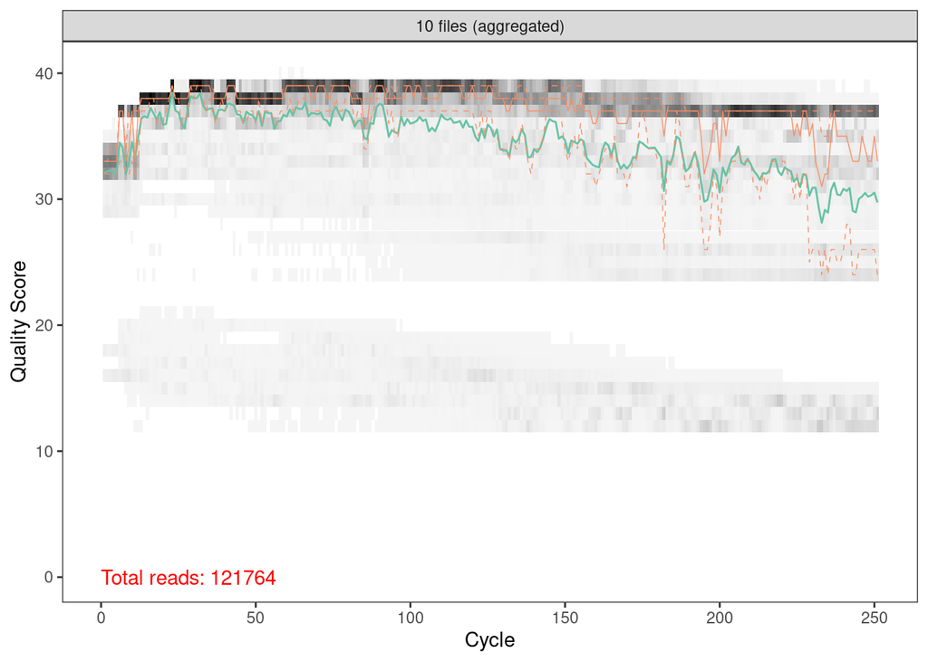

```r
plotQualityProfile(fnFs[c(1:10)], aggregate = T) # 10 LT samples
```

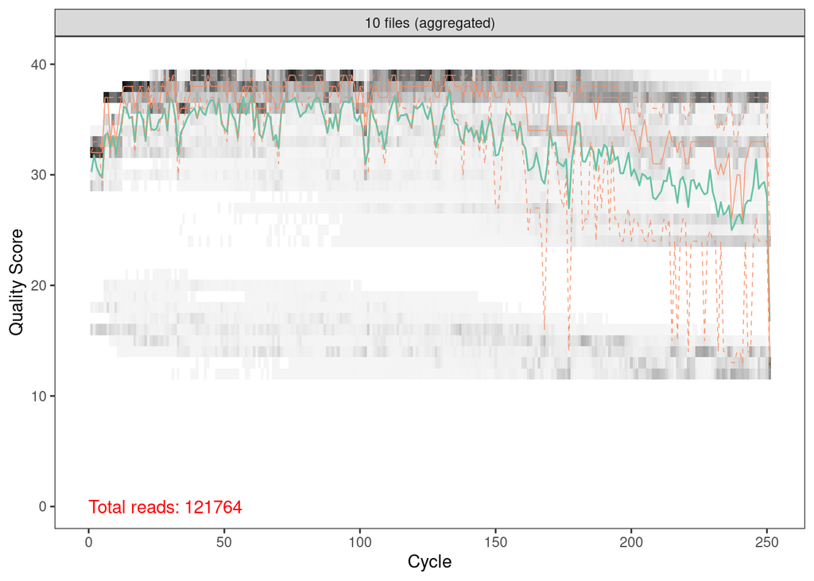

```r
plotQualityProfile(fnRs[c(1:10)], aggregate = T)
```

## 5.3 Filter and Trim

```r
filtFs <- file.path(filt.dir, "filtered", paste0(sample.names, "_F_filt.fastq.gz"))
filtRs <- file.path(filt.dir, "filtered", paste0(sample.names, "_R_filt.fastq.gz"))
names(filtFs) <- sample.names
names(filtRs) <- sample.names
```

```r
length(fnFs)
```

```
## [1] 11
```

```r
length(filtFs) # make sure the lengths match
```

```
## [1] 11
```

```r
filt.out <- filterAndTrim(fnFs, filtFs, fnRs, filtRs,maxN=0, maxEE=c(2, 2), truncQ=2, rm.phix=TRUE,
                          compress=TRUE, multithread=TRUE)  # Primer/barcode already removed so not setting truncation based on length
```

```
## Creating output directory: /work/yk132/GLP_KO_Microbiome_Study/filt/filtered
```

```r
                                                            # Otherwise same with fecal samples
```

All lung tissue samples survived the filtering step.

## 5.4 Error Correction

```r
filtFs.survived <- sort(list.files(path.expand(file.path(filt.dir,paste0("filtered"))), pattern="_F_filt.fastq.gz", full.names = TRUE))
filtRs.survived <- sort(list.files(path.expand(file.path(filt.dir,paste0("filtered"))), pattern="_R_filt.fastq.gz", full.names = TRUE))

end = "_F_filt.fastq.gz"
filtFs.survived %>%
  basename %>%
  str_replace(end, "") -> sample.names.filter

meta.df$Run -> sample.names

length(sample.names.filter)
```

```
## [1] 11
```

```r
length(sample.names)
```

```
## [1] 11
```

```r
sample.names[which(!sample.names %in% sample.names.filter)] # See which reads did not survive filter
```

```
## character(0)
```

```r
errF <- learnErrors(filtFs.survived, multithread=TRUE)
```

```
## 22189906 total bases in 88406 reads from 11 samples will be used for learning the error rates.
```

```r
errR <- learnErrors(filtRs.survived, multithread=TRUE)
```

```
## 22189906 total bases in 88406 reads from 11 samples will be used for learning the error rates.
```

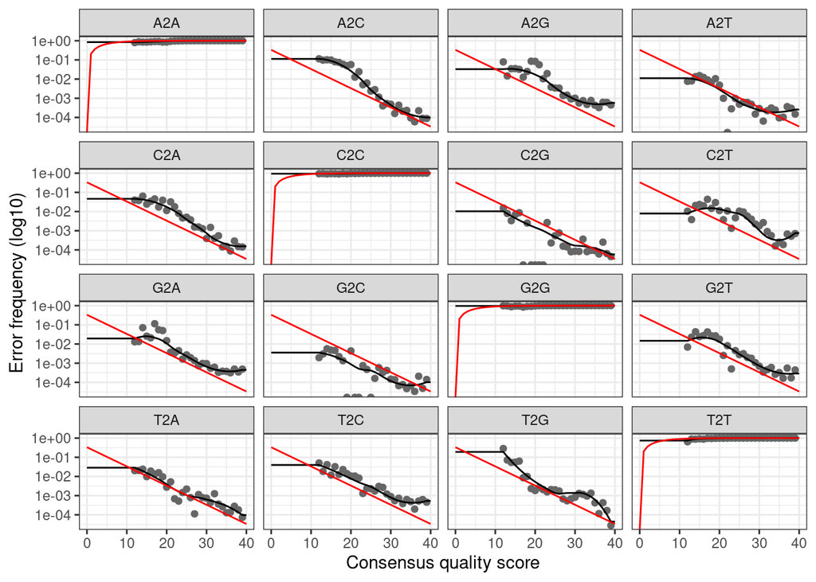

```r
plotErrors(errF, nominalQ=TRUE)
```

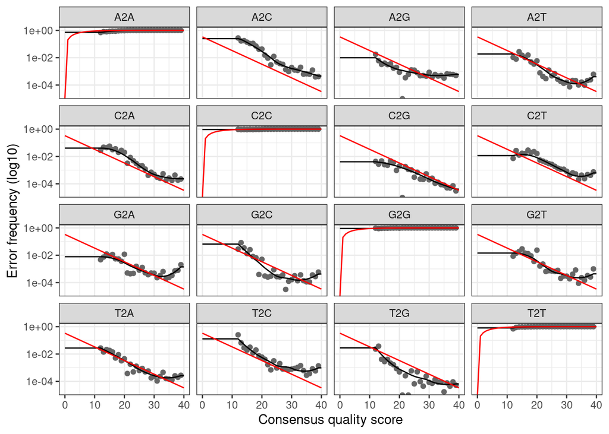

```r
plotErrors(errR, nominalQ=TRUE)
```

## 5.5 Dereplication

```r
derepFs <- derepFastq(filtFs.survived, verbose=TRUE)
```

```
## Dereplicating sequence entries in Fastq file: /work/yk132/GLP_KO_Microbiome_Study/filt/filtered/SRR29054920_F_filt.fastq.gz
```

```
## Encountered 377 unique sequences from 1548 total sequences read.
```

```
## Dereplicating sequence entries in Fastq file: /work/yk132/GLP_KO_Microbiome_Study/filt/filtered/SRR29054931_F_filt.fastq.gz
```

```
## Encountered 675 unique sequences from 3179 total sequences read.
```

```
## Dereplicating sequence entries in Fastq file: /work/yk132/GLP_KO_Microbiome_Study/filt/filtered/SRR29054934_F_filt.fastq.gz
```

```
## Encountered 1552 unique sequences from 6662 total sequences read.
```

```
## Dereplicating sequence entries in Fastq file: /work/yk132/GLP_KO_Microbiome_Study/filt/filtered/SRR29054939_F_filt.fastq.gz
```

```
## Encountered 632 unique sequences from 2675 total sequences read.
```

```
## Dereplicating sequence entries in Fastq file: /work/yk132/GLP_KO_Microbiome_Study/filt/filtered/SRR29054941_F_filt.fastq.gz
```

```
## Encountered 890 unique sequences from 4391 total sequences read.
```

```
## Dereplicating sequence entries in Fastq file: /work/yk132/GLP_KO_Microbiome_Study/filt/filtered/SRR29054946_F_filt.fastq.gz
```

```
## Encountered 137 unique sequences from 382 total sequences read.
```

```
## Dereplicating sequence entries in Fastq file: /work/yk132/GLP_KO_Microbiome_Study/filt/filtered/SRR29054949_F_filt.fastq.gz
```

```
## Encountered 106 unique sequences from 348 total sequences read.
```

```
## Dereplicating sequence entries in Fastq file: /work/yk132/GLP_KO_Microbiome_Study/filt/filtered/SRR29054968_F_filt.fastq.gz
```

```
## Encountered 325 unique sequences from 1429 total sequences read.
```

```
## Dereplicating sequence entries in Fastq file: /work/yk132/GLP_KO_Microbiome_Study/filt/filtered/SRR29055034_F_filt.fastq.gz
```

```
## Encountered 9955 unique sequences from 58861 total sequences read.
```

```
## Dereplicating sequence entries in Fastq file: /work/yk132/GLP_KO_Microbiome_Study/filt/filtered/SRR29055148_F_filt.fastq.gz
```

```
## Encountered 1140 unique sequences from 7220 total sequences read.
```

```
## Dereplicating sequence entries in Fastq file: /work/yk132/GLP_KO_Microbiome_Study/filt/filtered/SRR29055156_F_filt.fastq.gz
```

```
## Encountered 456 unique sequences from 1711 total sequences read.
```

```r
derepRs <- derepFastq(filtRs.survived, verbose=TRUE)
```

```
## Dereplicating sequence entries in Fastq file: /work/yk132/GLP_KO_Microbiome_Study/filt/filtered/SRR29054920_R_filt.fastq.gz
```

```
## Encountered 521 unique sequences from 1548 total sequences read.
```

```
## Dereplicating sequence entries in Fastq file: /work/yk132/GLP_KO_Microbiome_Study/filt/filtered/SRR29054931_R_filt.fastq.gz
```

```
## Encountered 1015 unique sequences from 3179 total sequences read.
```

```
## Dereplicating sequence entries in Fastq file: /work/yk132/GLP_KO_Microbiome_Study/filt/filtered/SRR29054934_R_filt.fastq.gz
```

```
## Encountered 2096 unique sequences from 6662 total sequences read.
```

```
## Dereplicating sequence entries in Fastq file: /work/yk132/GLP_KO_Microbiome_Study/filt/filtered/SRR29054939_R_filt.fastq.gz
```

```
## Encountered 715 unique sequences from 2675 total sequences read.
```

```
## Dereplicating sequence entries in Fastq file: /work/yk132/GLP_KO_Microbiome_Study/filt/filtered/SRR29054941_R_filt.fastq.gz
```

```
## Encountered 1370 unique sequences from 4391 total sequences read.
```

```
## Dereplicating sequence entries in Fastq file: /work/yk132/GLP_KO_Microbiome_Study/filt/filtered/SRR29054946_R_filt.fastq.gz
```

```
## Encountered 100 unique sequences from 382 total sequences read.
```

```
## Dereplicating sequence entries in Fastq file: /work/yk132/GLP_KO_Microbiome_Study/filt/filtered/SRR29054949_R_filt.fastq.gz
```

```
## Encountered 131 unique sequences from 348 total sequences read.
```

```
## Dereplicating sequence entries in Fastq file: /work/yk132/GLP_KO_Microbiome_Study/filt/filtered/SRR29054968_R_filt.fastq.gz
```

```
## Encountered 361 unique sequences from 1429 total sequences read.
```

```
## Dereplicating sequence entries in Fastq file: /work/yk132/GLP_KO_Microbiome_Study/filt/filtered/SRR29055034_R_filt.fastq.gz
```

```
## Encountered 18475 unique sequences from 58861 total sequences read.
```

```
## Dereplicating sequence entries in Fastq file: /work/yk132/GLP_KO_Microbiome_Study/filt/filtered/SRR29055148_R_filt.fastq.gz
```

```
## Encountered 1948 unique sequences from 7220 total sequences read.
```

```
## Dereplicating sequence entries in Fastq file: /work/yk132/GLP_KO_Microbiome_Study/filt/filtered/SRR29055156_R_filt.fastq.gz
```

```
## Encountered 472 unique sequences from 1711 total sequences read.
```

```r
names(derepFs) <- sample.names.filter
names(derepRs) <- sample.names.filter

dadaFs <- dada(derepFs, err=errF, multithread=TRUE)
```

```
## Sample 1 - 1548 reads in 377 unique sequences.
## Sample 2 - 3179 reads in 675 unique sequences.
## Sample 3 - 6662 reads in 1552 unique sequences.
## Sample 4 - 2675 reads in 632 unique sequences.
## Sample 5 - 4391 reads in 890 unique sequences.
## Sample 6 - 382 reads in 137 unique sequences.
## Sample 7 - 348 reads in 106 unique sequences.
## Sample 8 - 1429 reads in 325 unique sequences.
## Sample 9 - 58861 reads in 9955 unique sequences.
## Sample 10 - 7220 reads in 1140 unique sequences.
## Sample 11 - 1711 reads in 456 unique sequences.
```

```r
dadaRs <- dada(derepRs, err=errR, multithread=TRUE)
```

```
## Sample 1 - 1548 reads in 521 unique sequences.
## Sample 2 - 3179 reads in 1015 unique sequences.
## Sample 3 - 6662 reads in 2096 unique sequences.
## Sample 4 - 2675 reads in 715 unique sequences.
## Sample 5 - 4391 reads in 1370 unique sequences.
## Sample 6 - 382 reads in 100 unique sequences.
## Sample 7 - 348 reads in 131 unique sequences.
## Sample 8 - 1429 reads in 361 unique sequences.
## Sample 9 - 58861 reads in 18475 unique sequences.
## Sample 10 - 7220 reads in 1948 unique sequences.
## Sample 11 - 1711 reads in 472 unique sequences.
```

## 5.6 Merge Paired Reads

```r
mergers <- mergePairs(dadaFs, derepFs, dadaRs, derepRs, verbose=TRUE)
```

```
## 1539 paired-reads (in 15 unique pairings) successfully merged out of 1547 (in 17 pairings) input.
```

```
## 3148 paired-reads (in 24 unique pairings) successfully merged out of 3148 (in 24 pairings) input.
```

```
## 6536 paired-reads (in 57 unique pairings) successfully merged out of 6627 (in 68 pairings) input.
```

```
## 2665 paired-reads (in 10 unique pairings) successfully merged out of 2665 (in 10 pairings) input.
```

```
## 4332 paired-reads (in 33 unique pairings) successfully merged out of 4353 (in 34 pairings) input.
```

```
## 380 paired-reads (in 2 unique pairings) successfully merged out of 380 (in 2 pairings) input.
```

```
## 347 paired-reads (in 6 unique pairings) successfully merged out of 347 (in 6 pairings) input.
```

```
## 1399 paired-reads (in 8 unique pairings) successfully merged out of 1415 (in 9 pairings) input.
```

```
## 53974 paired-reads (in 172 unique pairings) successfully merged out of 57913 (in 527 pairings) input.
```

```
## 7085 paired-reads (in 29 unique pairings) successfully merged out of 7178 (in 31 pairings) input.
```

```
## 1711 paired-reads (in 9 unique pairings) successfully merged out of 1711 (in 9 pairings) input.
```

## 5.7 Check: sequence lengths

With the primers removed, the target amplicon region should be about 254 bp. Let’s check:

```r
seqtab <- makeSequenceTable(mergers)
table(nchar(getSequences(seqtab)))
```

```
##
## 251 252 253 254
##   1  55 260   5
```

They indeed peak at the expected length. Remove sequences that are unexpectedly long or short:

```r
seqtab2 <- seqtab[,nchar(colnames(seqtab)) %in% 250:256]
```

## 5.8 Chimera Removal

```r
seqtab.nochim <- removeBimeraDenovo(seqtab2, method="consensus", minFoldParentOverAbundance = 4, multithread=TRUE, verbose=TRUE)
```

```
## Identified 142 bimeras out of 321 input sequences.
```

```r
dim(seqtab.nochim)
```

```
## [1]  11 179
```

```r
sum(seqtab.nochim)/sum(seqtab2)
```

```
## [1] 0.9120988
```

About ~9% was identified as bimeras.

## 5.9 Assign taxonomy

For plotting purposes, having ASV numbers (ex. ASV1-ASV999) is easier, but it’s also useful to have the whole DNA sequences as the RefSeq object.

```r
taxa <- assignTaxonomy(seqtab.nochim, silva_v138.ref, multithread=TRUE)
# taxa <- addSpecies(taxa, silva_v138.species.ref) # identify species when possible
taxa.print <- taxa # Removing sequence rownames for display only
rownames(taxa.print) <- NULL
head(taxa.print)
```

```
##      Kingdom    Phylum           Class
## [1,] "Bacteria" "Proteobacteria" "Gammaproteobacteria"
## [2,] "Bacteria" "Firmicutes"     "Clostridia"
## [3,] "Bacteria" "Firmicutes"     "Negativicutes"
## [4,] "Bacteria" "Bacteroidota"   "Bacteroidia"
## [5,] "Bacteria" "Firmicutes"     "Negativicutes"
## [6,] "Bacteria" "Firmicutes"     "Negativicutes"
##      Order                            Family
## [1,] "Enterobacterales"               "Enterobacteriaceae"
## [2,] "Oscillospirales"                "Ruminococcaceae"
## [3,] "Veillonellales-Selenomonadales" "Veillonellaceae"
## [4,] "Bacteroidales"                  "Bacteroidaceae"
## [5,] "Veillonellales-Selenomonadales" "Veillonellaceae"
## [6,] "Veillonellales-Selenomonadales" "Veillonellaceae"
##      Genus
## [1,] "Escherichia-Shigella"
## [2,] "Faecalibacterium"
## [3,] "Veillonella"
## [4,] "Bacteroides"
## [5,] "Veillonella"
## [6,] "Veillonella"
```

```r
meta.df %>% column_to_rownames("Run") -> meta.df # Change Run into rownames for passing off to phyloseq
meta.df
```

|  | Label | Concentration-(ng/uL) | Sample_type | Type | Sequencing_Run | Mouse | Cage-Mouse | Genotype | Sex | Diet | Intranasal_Treatment | Surgery | Intranasal_Dose | Cohort | Cage | Week | Lung_index | Kit | DNA_ng_ul_raw | Sample_Label | Cage_Notation | Feces_weight | Orig_label | Notes | Glucose_tolerance_wk0_0m | Glucose_tolerance_wk0_10m | Glucose_tolerance_wk0_30m | Glucose_tolerance_wk0_90m | Weight_g_wk0 | … |
| --- | --- | --- | --- | --- | --- | --- | --- | --- | --- | --- | --- | --- | --- | --- | --- | --- | --- | --- | --- | --- | --- | --- | --- | --- | --- | --- | --- | --- | --- | --- |
| SRR29054920 | JI-688 | NA | Lung Tissue | True Sample | 1 | JI-688 | 1477807/1467746-1 | KO | Female | High_Fat_Diet | HDM | VSG | 50ug/40ul | 1 | 1477807 | 13 | 40 | BT_1 | 42.00 | NA | NA | NA | NA | NA | NA | NA | NA | NA | 19.34 | … |
| SRR29054931 | JI-678 | NA | Lung Tissue | True Sample | 1 | JI-678 | 1420963-2 | WT | Female | Normal_Chow | PBS | None | 40ul | 1 | 1420963 | 13 | 20 | BT_1 | 480.00 | NA | NA | NA | NA | NA | NA | NA | NA | NA | 19.57 | … |
| SRR29054934 | JI-676 | NA | Lung Tissue | True Sample | 1 | JI-676 | 1477833/1420957-4 | KO | Male | High_Fat_Diet | PBS | VSG | 40ul | 1 | 1477833 | 13 | 32 | BT_1 | 790.00 | NA | NA | NA | NA | NA | NA | NA | NA | NA | 27.73 | … |
| SRR29054939 | JI-670 | NA | Lung Tissue | True Sample | 1 | JI-670 | 1477830/1420961-3 | WT | Female | High_Fat_Diet | HDM | Sham | 50ug/40ul | 1 | 1477830 | 13 | 43 | BT_1 | 132.00 | NA | NA | NA | NA | NA | NA | NA | NA | NA | 20.06 | … |
| SRR29054941 | JI-668 | NA | Lung Tissue | True Sample | 1 | JI-668 | 1477834/1420957-1 | KO | Male | High_Fat_Diet | HDM | Sham | 50ug/40ul | 1 | 1477834 | 13 | 5 | BT_1 | 488.00 | NA | NA | NA | NA | NA | NA | NA | NA | NA | 28.38 | … |
| SRR29054946 | Saline-blank-3 | NA | Lung Tissue | Neg Control | 1 | Saline_blank | NA | NA | NA | NA | NA | NA | NA | NA | NA | NA | 25 | BT_1 | 0.01 | NA | NA | NA | NA | NA | NA | NA | NA | NA | NA | … |
| SRR29054949 | PCR-neg1-eva | NA | Lung Tissue | Neg Control | 1 | PCR_neg_DMC | NA | NA | NA | NA | NA | NA | NA | NA | NA | NA | NA | NA | 0.23 | NA | NA | NA | NA | NA | NA | NA | NA | NA | NA | … |
| SRR29054968 | Kit-blank-2 | NA | Lung Tissue | Neg Control | 1 | Kit_blank | NA | NA | NA | NA | NA | NA | NA | NA | NA | NA | 26 | BT_1 | 1.06 | NA | NA | NA | NA | NA | NA | NA | NA | NA | NA | … |
| SRR29055034 | zymo-eva | NA | Lung Tissue | Pos Control | 1 | zymo_DMC_Pos | NA | NA | NA | NA | NA | NA | NA | NA | NA | NA | NA | NA | NA | NA | NA | NA | NA | NA | NA | NA | NA | NA | NA | … |
| SRR29055148 | JI-650 | NA | Lung Tissue | True Sample | 1 | JI-650 | 1420961-1 | WT | Female | High_Fat_Diet | HDM | None | 50ug/40ul | 1 | 1420961 | 10 | 16 | BT_1 | 403.00 | NA | NA | NA | NA | NA | NA | NA | NA | NA | 19.04 | … |

[output cut: 1 more lines]

```r
rownames(seqtab.nochim)
```

```
##  [1] "SRR29054920" "SRR29054931" "SRR29054934" "SRR29054939" "SRR29054941"
##  [6] "SRR29054946" "SRR29054949" "SRR29054968" "SRR29055034" "SRR29055148"
## [11] "SRR29055156"
```

```r
all(rownames(seqtab.nochim) %in% rownames(meta.df))
```

```
## [1] TRUE
```

All rownames match.

## 5.10 Save and export as phyloseq object

```r
otus = otu_table(seqtab.nochim, taxa_are_rows=FALSE)
sd = sample_data(meta.df)
ps <- phyloseq(otus,
               sd,
               tax_table(taxa))
```

```r
dna <- Biostrings::DNAStringSet(taxa_names(ps))
names(dna) <- taxa_names(ps)
ps <- merge_phyloseq(ps, dna)
taxa_names(ps) <- paste0("ASV", seq(ntaxa(ps))) # Give taxa ASV names for easier graphing
ps
```

```
## phyloseq-class experiment-level object
## otu_table()   OTU Table:         [ 179 taxa and 11 samples ]
## sample_data() Sample Data:       [ 11 samples by 40 sample variables ]
## tax_table()   Taxonomy Table:    [ 179 taxa by 6 taxonomic ranks ]
## refseq()      DNAStringSet:      [ 179 reference sequences ]
```

```r
ps.rds = file.path(git.dir, paste0("ps.Run1.rds"))
write_rds(ps, ps.rds)
loaded.ps = read_rds(ps.rds)
print(loaded.ps)
```

```
## phyloseq-class experiment-level object
## otu_table()   OTU Table:         [ 179 taxa and 11 samples ]
## sample_data() Sample Data:       [ 11 samples by 40 sample variables ]
## tax_table()   Taxonomy Table:    [ 179 taxa by 6 taxonomic ranks ]
## refseq()      DNAStringSet:      [ 179 reference sequences ]
```

The phyloseq object was written and saved correctly.